# Exercise 7: scDRS Cell-Type Analysis

Post-GWAS Analysis Course

# Overview

**NoteLearning goals**

By the end of this notebook, you should be able to: - prepare the gene-set and single-cell inputs needed by scDRS - run the scoring and group-level association steps - interpret scDRS output in the context of cell-type enrichment and sensitivity analysis

## Table of Contents

- Set up
- Single cell RNA sequencing dataset
- Prepare the input files for scDRS
  - Covariance file
  - Gene set file
- Run scDRS
- Run group-level association

# 1. Set up

```python
#Load the different libraries
import scdrs
import scanpy as sc
from anndata import AnnData
import pandas as pd
import numpy as np
import os
import warnings

warnings.filterwarnings("ignore")
```

# 2. Single-cell RNA sequencing dataset: dopaminergic neuron differentiation

For this example we are going to use a dataset that was build by differentiating “215 human induced pluripotent stem cell (iPSC) lines toward a midbrain neural fate, including dopaminergic neurons, and use single-cell RNA sequencing (scRNA-seq) to profile over 1 million cells across three differentiation time points.” The original publication can be found here: https://pubmed.ncbi.nlm.nih.gov/33664506/  
The dataset is divided into differentiating neurons cultivated for 11, 30, or 52 days

```python
#Load the dataset in H5AD format
#We focus here on the 11day neurons

adata = sc.read_h5ad("./reference_data/scDRS_Jerber_dataset/11day_DA_neurons.h5ad")
```

The scRNA seq dataset is organised in H5AD format, and can be read using the library AnnData (https://anndata.readthedocs.io/en/latest/). H5AD files have the following structure:

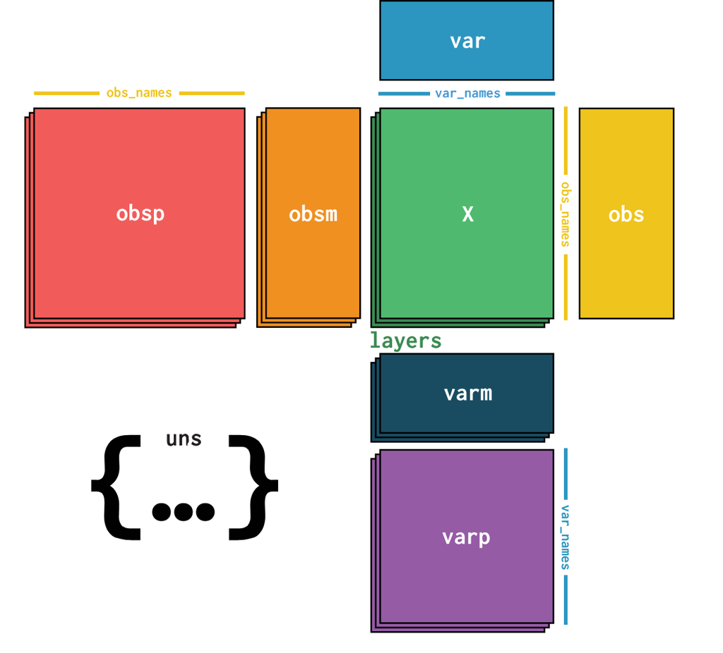

```python
# Explore the structure of the dataset and answer the following questions:
adata
```

```
AnnData object with n_obs × n_vars = 253381 × 32738
    obs: 'sample_index', 'sample_id', 'donor_id', 'cluster_id', 'celltype', 'time_point', 'pool_id', 'treatment'
    var: 'gene_ids-0', 'gene_ids-1', 'gene_ids-2', 'gene_ids-3', 'gene_ids-4', 'gene_ids-5', 'gene_ids-6', 'gene_ids-7', 'gene_ids-8', 'gene_ids-9', 'gene_ids-10', 'gene_ids-11', 'gene_ids-12', 'gene_ids-13', 'gene_ids-14', 'gene_ids-15', 'gene_ids-16', 'gene_ids-17', 'gene_ids-18', 'gene_ids-19', '…
    obsm: 'X_umap'
```

**Note**

**Questions**

- How many cells are contained in the dataset?
- How many genes?
- What type of information contains ‘obs’?
- What type of information contains ‘var’?
- What type of infomation contains ‘obsm’?

```python
# You can also view a snippet of the table using
adata.obs
```

| index | sample_index | sample_id | donor_id | cluster_id | celltype | time_point | pool_id | treatment |
| --- | --- | --- | --- | --- | --- | --- | --- | --- |
| AAACCTGAGAACAACT-1-0 | 0 | 5245STDY7352549 | HPSI0714i-iudw_1 | 2 | P_FPP | D11 | pool1 | NONE |
| AAACCTGAGACAAGCC-1-0 | 0 | 5245STDY7352549 | HPSI0614i-liqa_1 | 1 | P_FPP | D11 | pool1 | NONE |
| AAACCTGAGACGCACA-1-0 | 0 | 5245STDY7352549 | HPSI1113i-podx_1 | 1 | P_FPP | D11 | pool1 | NONE |
| AAACCTGAGGAATGGA-1-0 | 0 | 5245STDY7352549 | HPSI0114i-eipl_1 | 0 | FPP | D11 | pool1 | NONE |
| AAACCTGCACGTCTCT-1-0 | 0 | 5245STDY7352549 | HPSI0914i-suop_5 | 1 | P_FPP | D11 | pool1 | NONE |
| ... | ... | ... | ... | ... | ... | ... | ... | ... |
| TTTGGTTTCTTCAACT-1-37 | 37 | 5245STDY7962568 | HPSI0813i-guss_1 | 0 | FPP | D11 | pool13 | NONE |
| TTTGTCAAGCTGCAAG-1-37 | 37 | 5245STDY7962568 | HPSI0813i-peoj_1 | 0 | FPP | D11 | pool13 | NONE |
| TTTGTCAGTAACGCGA-1-37 | 37 | 5245STDY7962568 | HPSI0714i-kute_5 | 0 | FPP | D11 | pool13 | NONE |
| TTTGTCAGTGTCAATC-1-37 | 37 | 5245STDY7962568 | HPSI0813i-zexw_3 | 2 | P_FPP | D11 | pool13 | NONE |
| TTTGTCATCCAACCAA-1-37 | 37 | 5245STDY7962568 | HPSI1013i-jufd_3 | 0 | FPP | D11 | pool13 | NONE |

253381 rows × 8 columns

**Note**

**Question.** What format do gene names have in the dataset?

# 3. Prepare the input files for scDRS

scDRS requires 3 different files as input: the H5AD file containing the scRNA seq data, a covariate file associated to the H5AD file, and the gene set file. A description of the different input and output file formats for scDRS can be found here: https://martinjzhang.github.io/scDRS/file_format.html

## 3.1 Covariate file

The covariate file (.cov) contains information about the covariate we would like to include in the analysis. The first column corresponds to the cell names (matching adata.obs_names), and the other columns contain the covariates (e.g. n_genes, sex_male, age…) for each cell.  
The covariates you decide to include should be adapted to the dataset you are using and how it was created.  
Here, we will include the donor ID, the number of genes expressed by the cell, and a constant.

```python
os.makedirs("./output/scdrs/", exist_ok=True)
```

```python
#Initiate the covariate table
cov = adata

#Create a column with the number of genes:
sc.pp.filter_cells(cov, min_genes=0)

#New donor column:
cov.obs["donor_idv2"] = cov.obs["donor_id"].astype("category").cat.codes

#Add a column containing a constant value
cov.obs["const"] = 1

#Select the columns we need and save the file
file_cov = cov.obs[["const", "n_genes", "donor_idv2"]]
file_cov.to_csv("./output/scdrs/jeber_11day_neurons.cov", sep = "\t")
```

## 3.2 Gene set file

The gene set file (.gs) contains the list of gene for each trait we want to consider. The first column contains the trait name, and the second column contains the geneset. The geneset corresponds to the gene id, and the MAGMA z-score or p-value for that gene.

For this example, we want to build a .gs file with the top 100 genes identified by MAGMA.The necessary input file was generated with MAGMA earlier in the related notebook.

```python
#Load the output files from MAGMA
magma_out = pd.read_fwf("./output/magma/adhd.genes.out")
magma_out.head()
```

|  | GENE | CHR | START | STOP | NSNPS | NPARAM | N | ZSTAT | P |
| --- | --- | --- | --- | --- | --- | --- | --- | --- | --- |
| 0 | 84069 | 1 | 891872 | 920488 | 7 | 1 | 128214 | 0.65538 | 0.25611 |
| 1 | 84808 | 1 | 900579 | 927473 | 20 | 3 | 128214 | 1.22680 | 0.10994 |
| 2 | 57801 | 1 | 924342 | 946608 | 29 | 3 | 128214 | 0.87823 | 0.18991 |
| 3 | 9636 | 1 | 938847 | 959920 | 15 | 1 | 128214 | 0.47696 | 0.31669 |
| 4 | 375790 | 1 | 945503 | 1001499 | 7 | 1 | 128214 | 0.63903 | 0.26140 |

```python
#As we can see in the first few rows of the MAGMA output, the genes are designated by numbers.
#We use a file with the MAGMA gene numbers and corresponding gene symbols to fix that

#Load the reference file with gene number and corresponding gene symbol
ncbi_ref = pd.read_csv("./reference_data/NCBI37.3.gene.loc", sep = "\t", header = None)
ncbi_ref = ncbi_ref.iloc[:,[0,5]]
ncbi_ref.columns = ["GENE","GENE_symbol"]
ncbi_ref.head()
```

|  | GENE | GENE_symbol |
| --- | --- | --- |
| 0 | 79501 | OR4F5 |
| 1 | 100996442 | LOC100996442 |
| 2 | 729759 | OR4F29 |
| 3 | 81399 | OR4F16 |
| 4 | 148398 | SAMD11 |

```python
#Create a table with the gene name and the corresponding z-score
#be sure everything is a string
magma_out['GENE'] = magma_out['GENE'].astype(str)
ncbi_ref['GENE'] = ncbi_ref['GENE'].astype(str)

#Add the gene symbol column
df = magma_out.merge(ncbi_ref, how = 'inner', on = 'GENE')

#Select the columns we need for scDRS
df = df[['GENE_symbol', 'ZSTAT']]

#Rename the ZSTAT column with the name of the trait
df.columns = ["GENE", "ADHD"]
df.head()

#Save the file
df.to_csv("./output/scdrs/zfile_adhd_magma.tsv", sep = "\t", index = False)
```

```python
#Use scdrs munge-gs to create the .gs file
#We munge the file to keep the TOP 100 GENES

munge_command = "scdrs munge-gs \
--out-file ./output/scdrs/munge_adhd_magma_100.gs \
--zscore-file ./output/scdrs/zfile_adhd_magma.tsv \
--weight zscore \
--n-max 100"

os.system(munge_command)
```

```
* Single-cell disease relevance score (scDRS)
* Version 1.0.2
* Martin Jinye Zhang and Kangcheng Hou
* HSPH / Broad Institute / UCLA
* MIT License
Call: scdrs munge-gs \
--zscore-file ./output/scdrs/zfile_adhd_magma.tsv \
--weight zscore \
--n-min 100 \
--n-max 100 \
--out-file ./output/scdrs/munge_adhd_magma_100.gs

--zscore-file loaded: n_gene=18112, n_trait=1 (sys_time=0.0s)
Print info for the first 3 traits and first 10 genes
Traits               ['ADHD']
PLEKHN1              [0.65538]
PERM1                [1.2268]
HES4                 [0.87823]
ISG15                [0.47696]
AGRN                 [0.63903]
C1orf159             [0.44094]
TTLL10               [0.63568]
TNFRSF18             [-1.5323]
TNFRSF4              [-1.4947]
UBE2J2               [-0.31362]
--zscore-file have values above 1 or below 0. Seems fine.

Finish munging 1 gene sets (sys_time=0.0s)
```

```
0
```

**Note**

Open and inspect the munged gene set . **Question.** What does the output of the munging step look like? You can also directly check the file from the file browser in jupyterLab.

## 4. Run scDRS on the 11day neurons dataset

We now have prepared all the input files necessary to run scDRS.  
We can run the compute-score function, which will calculate a score for each cell in the dataset. This command takes as input the h5ad file, the covariate file, the gene set file, and additional arguments related to which score to return.

```python
#This step takes long
#remove hashtag to os.system below to run it anyway

scdrs_command = "scdrs compute-score \
--h5ad-file ./reference_data/scDRS_Jerber_dataset/11day_DA_neurons.h5ad \
--h5ad-species human \
--gs-file ./output/scdrs/munge_adhd_magma_100.gs \
--gs-species human \
--cov-file ./reference_data/scDRS_Jerber_dataset/11day_DA_neurons_wSex.tsv \
--flag-filter-data True \
--flag-raw-count True \
--flag-return-ctrl-raw-score False \
--flag-return-ctrl-norm-score True \
--out-folder ./output/scdrs/ "

#os.system(scdrs_command)

print(f"The command to use is below. We do not run it as it takes some time, but we have already generated the output files.\n{scdrs_command}")
```

```
The command to use is below. We do not run it as it takes some time, but we have already generated the output files.
scdrs compute-score --h5ad-file ./reference_data/scDRS_Jerber_dataset/11day_DA_neurons.h5ad --h5ad-species human --gs-file ./output/scdrs/munge_adhd_magma_100.gs --gs-species human --cov-file ./reference_data/scDRS_Jerber_dataset/11day_DA_neurons_wSex.tsv --flag-filter-data True --flag-raw-count Tru…
```

**Note**

**Question.** Can you tell why the software outputs two files .score.gz and .full_score.gz?

## 5. Run the group level analysis

Now that we have computed the disease score for each cell, we can compute group-level associations. Here, the groups that we will consider are the different cell types in the dataset.  
We use the perform-downstream command, which will calculate an association p-value for each cell type in the dataset, based on the disease score for each cell, and the scores for control gene sets. The function takes as input the h5ad file, the covariate file, the scores calculated for each cell, and the name of the group-level we want to analyse.

```python
#This step takes long
#remove hashtag to os.system below to run it anyway

group_level_command = "scdrs perform-downstream \
--h5ad-file ./reference_data/scDRS_Jerber_dataset/11day_DA_neurons.h5ad \
--score-file ./output/scdrs/ADHD.full_score.gz \
--out-folder ./output/scdrs/ \
--group-analysis celltype \
--flag-filter-data True \
--flag-raw-count True"

#os.system(group_level_command)

print(f"The command to use is below. We do not run it as it takes some time, but we have already generated the output files.\n{group_level_command}")
```

```
The command to use is below. We do not run it as it takes some time, but we have already generated the output files.
scdrs perform-downstream --h5ad-file ./reference_data/scDRS_Jerber_dataset/11day_DA_neurons.h5ad --score-file ./output/scdrs/ADHD.full_score.gz --out-folder ./output/scdrs/ --group-analysis celltype --flag-filter-data True --flag-raw-count True
```

**Note**

**Question.** How is the output file organised? You can use the file format page to understand the different columns.